# The normal distribution

```r
library(mosaic)
library(oilabs)
library(ggformula)
```

In this lab we’ll investigate the probability distribution that is most central to statistics: the normal distribution. If we are confident that our data are nearly normal, that opens the door to many powerful statistical methods. Here we’ll use the graphical tools of R to assess the normality of our data and  
learn how to generate random numbers from a normal distribution.

## The Data

This week we’ll be working with measurements of body dimensions. This data set contains measurements from 247 men and 260 women, most of whom were considered healthy young adults. Let’s take a quick peek at the first few rows of the data:

```r
data(bdims)
head(bdims)
```

[output not shown]

You’ll see that for every observation we have 25 measurements, many of which are either diameters or girths. You can learn about what the variable names mean by bringing up the help page:

```r
?bdims
```

We’ll be focusing on just three columns to get started: weight in kg (`wgt`), height in cm (`hgt`), and `sex` (`m` indicates male, `f` indicates female).

Since males and females tend to have different body dimensions, it will be useful to create two additional data sets: one with only men and another with only women.

```r
mdims <- bdims %>%
  filter(sex == "m")
fdims <- bdims %>%
  filter(sex == "f")
```

1. Make a plot (or plots) to compare the distributions of men’s and women’s heights. How would you compare the various aspects of the two distributions?

## The normal distribution

In your description of the distributions, did you use words like *bell-shaped* or *normal*? It’s tempting to say so when faced with a unimodal symmetric distribution.

To see how accurate that description is, we can plot a normal distribution curve on top of a histogram to see how closely the data follow a normal distribution. This normal curve should have the same mean and standard deviation as the data. We’ll be working with women’s heights, so let’s store them as a separate object and then calculate some statistics that will be referenced later.

```r
meanFheight <- mean(~ hgt, data = fdims)
sdFheight <- sd(~ hgt, data = fdims)
```

Writing `gf_histogram` produces a frequency histogram, which shows the number of data points that fall into a particular bin. In a frequency histogram, the *heights* of the bars add up to the total number of observations.

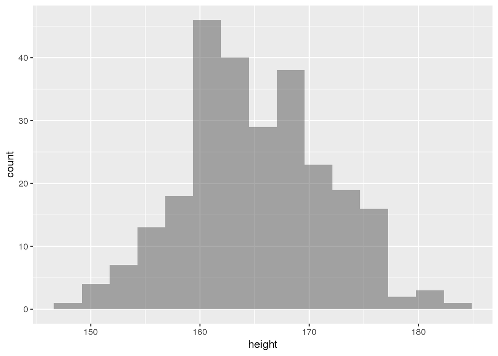

```r
gf_histogram(~ hgt, data = fdims, bins = 15, xlab = "height")
```

In a density histogram the *areas* of the bars add up to 1. The area of each bar can be calculated as simply the height *times* the width of the bar.

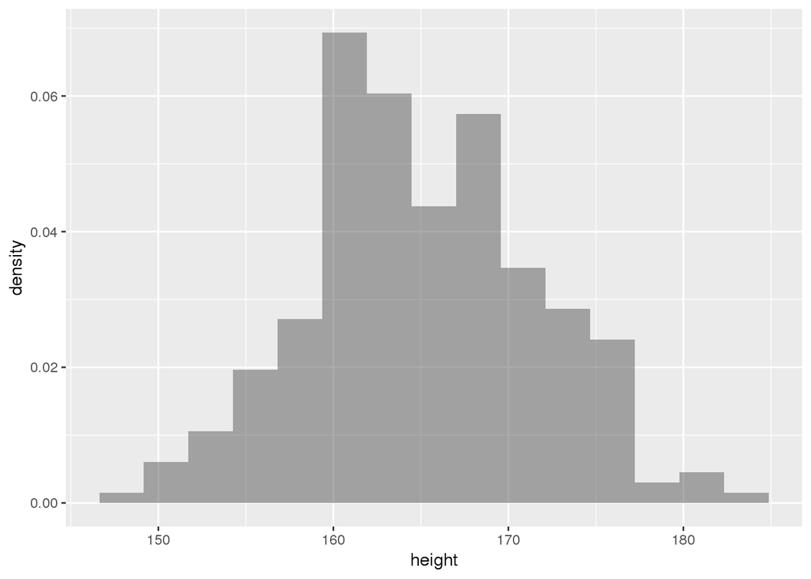

```r
gf_dhistogram(~ hgt, data = fdims, bins = 15, xlab = "height")
```

Frequency and density histograms all display the same shape; they only differ in their $y$-axis. You can verify this by comparing the two histograms we just constructed.

Next we want to make a density histogram to use as the backdrop and overlay a normal probability curve. The function `gf_dhistogram()` creates a density histogram, and piping it into the `gf_fitdistr` function will accomplish the second task. Using a density histogram allows us to properly overlay a normal distribution curve over the histogram since the curve is a normal probability density function.

[figure not shown]

```r
gf_dhistogram(~ hgt, data = fdims, bins = 15, xlab = "height") %>%
  gf_fitdistr(dist = dnorm)
```

The optional `bins` argument simply specificies the number of bins.

2. Based on the this plot, does it appear that the data follow a nearly normal distribution?

## Evaluating the normal distribution

Eyeballing the shape of the histogram is one way to determine if the data appear to be nearly normally distributed, but it can be frustrating to decide just how close the histogram is to the curve. An alternative approach involves constructing a normal probability plot, also called a normal Q-Q plot for “quantile-quantile”.

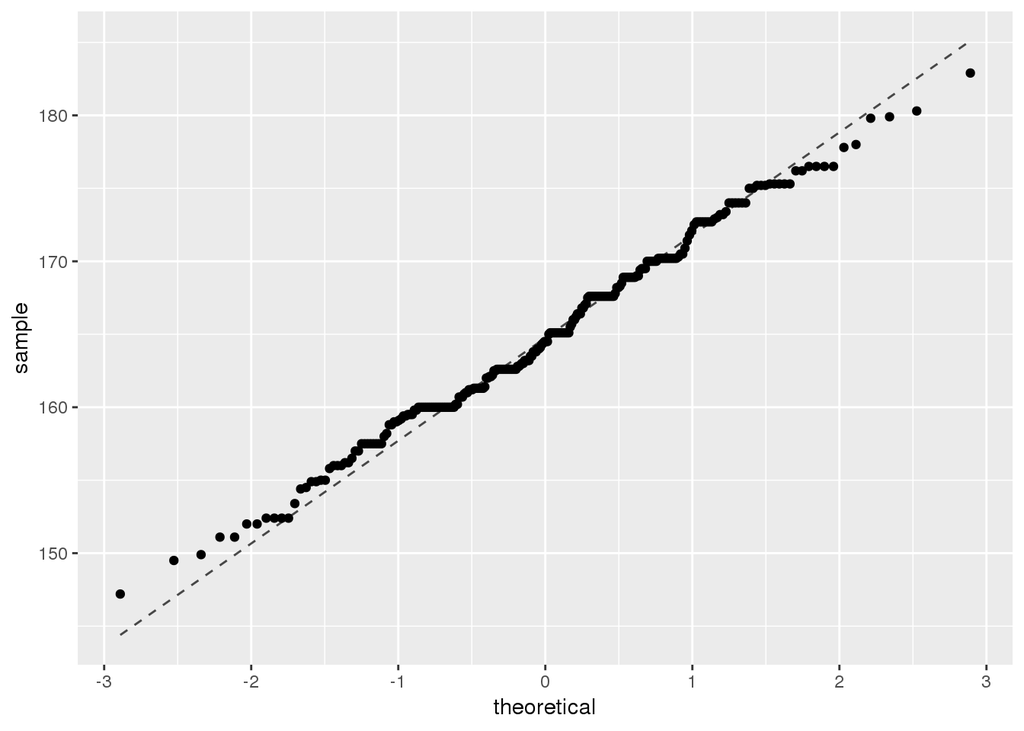

```r
gf_qq(~ hgt, data = fdims) %>%
  gf_qqline()
```

A data set that is nearly normal will result in a probability plot where the points closely follow a line. Any deviations from normality leads to deviations of these points from the line. The plot for female heights shows points that tend to follow the line but with some errant points towards the tails. We’re left with the same problem that we encountered with the histogram above: how close is close enough?

The x-axis values correspond to the quantiles of a theoretically normal curve with mean 0 and standard deviation 1 (a.k.a. the standard normal distribution). The y-axis values correspond to the quantiles of the original unstandardized sample data. However, even if we were to standardize the sample data values, the Q-Q plot would look identical. A data set that is nearly normal will result in a probability plot where the points closely follow the line. Any deviations from normality leads to deviations of these points from the line.

The plot for female heights shows points that tend to follow the line but with some errant points towards the tails. We’re left with the same problem that we encountered with the histogram above: how close is close enough?

A useful way to address this question is to rephrase it as: what do probability plots look like for data that I *know* came from a normal distribution? We can answer this by simulating data from a normal distribution using `rnorm`.

```r
sim_norm <- rnorm(n = nrow(fdims), mean = meanFheight, sd = sdFheight)
```

The first argument indicates how many numbers you’d like to generate, which we specify to be the same number of heights in the `fdims` data set using the `nrow` function. The last two arguments determine the mean and standard deviation of the normal distribution from which the simulated sample will be generated. We can take a look at the shape of our simulated data set, `sim_norm`, as well as its normal probability plot.

3. Make a normal probability plot of `sim_norm`. Do all of the points fall on the line? How does this plot compare to the probability plot for the real data?

Even better than comparing the original plot to a single plot generated from a normal distribution is to compare it to many more plots using the following function. It shows the Q-Q plot corresponding to the original data in the top left corner, and the Q-Q plots of 8 different simulated normal data. It may be helpful to click the zoom button in the plot window.

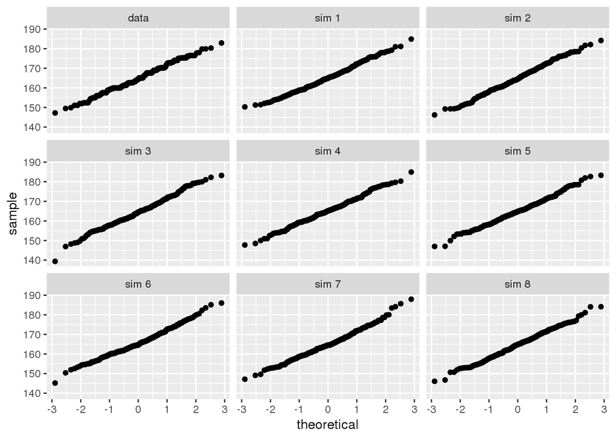

```r
qqnormsim(hgt, data = fdims)
```

4. Does the normal probability plot for `hgt` look similar to the plots created for the simulated data? That is, do plots provide evidence that the female heights are nearly normal?
5. Using the same technique, determine whether or not female weights appear to come from a normal distribution.

## Normal probabilities

Okay, so now you have a slew of tools to judge whether or not a variable is normally distributed. Why should we care?

It turns out that statisticians know a lot about the normal distribution. Once we decide that a random variable is approximately normal, we can answer all sorts of questions about that variable related to probability. Take, for example, the question of, “What is the probability that a randomly chosen young adult female is taller than 6 feet (about 182 cm)?” (The study that published this data set is clear to point out that the sample was not random and therefore inference to a general population is not suggested. We do so here only as an exercise.)

If we assume that female heights are normally distributed (a very close approximation is also okay), we can find this probability by calculating a Z score and consulting a Z table (also called a normal probability table). In R, this is done in one step with the function `xpnorm()`.

```r
1 - xpnorm(q = 182, mean = meanFheight, sd = sdFheight)
```

```
## If X ~ N(164.9, 6.545), then
```

```
##  P(X <= 182) = P(Z <= 2.617) = 0.9956
```

```
##  P(X >  182) = P(Z >  2.617) = 0.004434
```

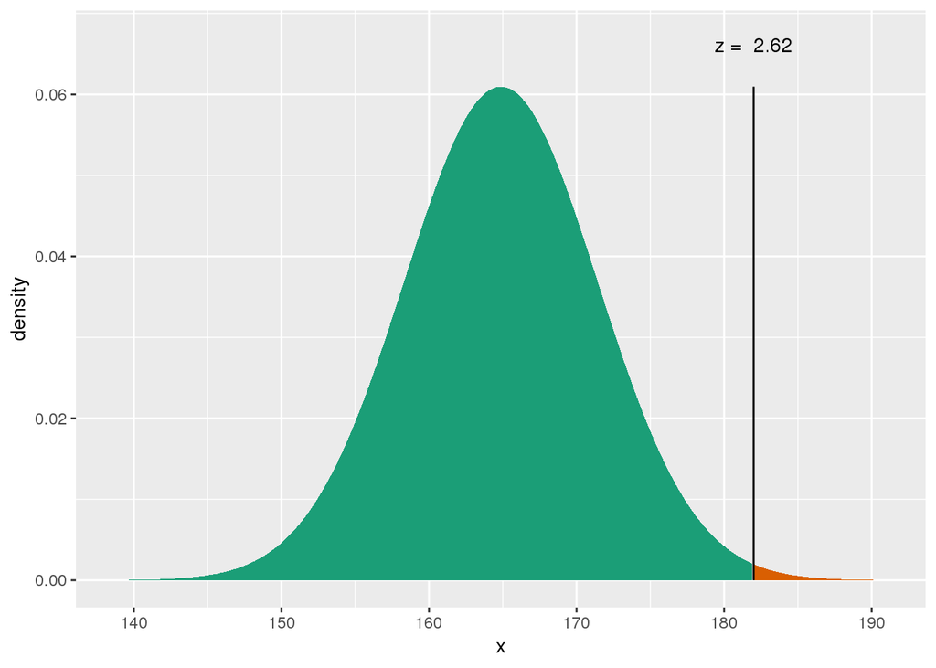

```
## [1] 0.004434387
```

Note that the function `xpnorm()` gives the area under the normal curve below a given value, `q`, with a given mean and standard deviation.

Since we’re interested in the probability that someone is taller than 182 cm, we have to take one minus that probability.

Assuming a normal distribution has allowed us to calculate a theoretical probability. If we want to calculate the probability empirically, we simply need to determine how many observations fall above 182 then divide this number by the total sample size.

```r
fdims %>%
  filter(hgt > 182) %>%
  summarise(percent = n() / nrow(fdims))
```

```
## # A tibble: 1 x 1
##   percent
##     <dbl>
## 1 0.00385
```

Although the probabilities are not exactly the same, they are reasonably close. The closer that your distribution is to being normal, the more accurate the theoretical probabilities will be.

6. Write out two probability questions that you would like to answer; one regarding female heights and one regarding female weights. Calculate the those probabilities using both the theoretical normal distribution as well as the empirical distribution (four probabilities in all). Which variable, height or weight, had a closer agreement between the two methods?

## On Your Own

- Now let’s consider some of the other variables in the body dimensions data set. Using the figures at the end of the exercises, match the histogram to its normal probability plot. All of the variables have been standardized (first subtract the mean, then divide by the standard deviation), so the units won’t be of any help. If you are uncertain based on these figures, generate the plots in R to check.

  **a.** The histogram for female biiliac (pelvic) diameter (`bii.di`) belongs to normal probability plot letter ____.

  **b.** The histogram for female elbow diameter (`elb.di`) belongs to normal probability plot letter ____.

  **c.** The histogram for general age (`age`) belongs to normal probability plot letter ____.

  **d.** The histogram for female chest depth (`che.de`) belongs to normal probability plot letter ____.
- Note that normal probability plots C and D have a slight stepwise pattern.  
  Why do you think this is the case?
- As you can see, normal probability plots can be used both to assess normality and visualize skewness. Make a normal probability plot for female knee diameter (`kne.di`). Based on this normal probability plot, is this variable left skewed, symmetric, or right skewed? Use a histogram to confirm your findings.

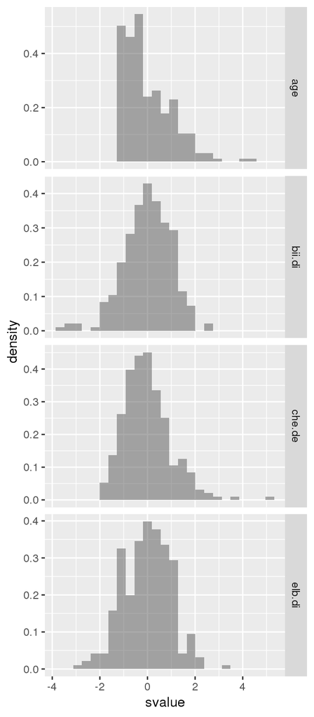

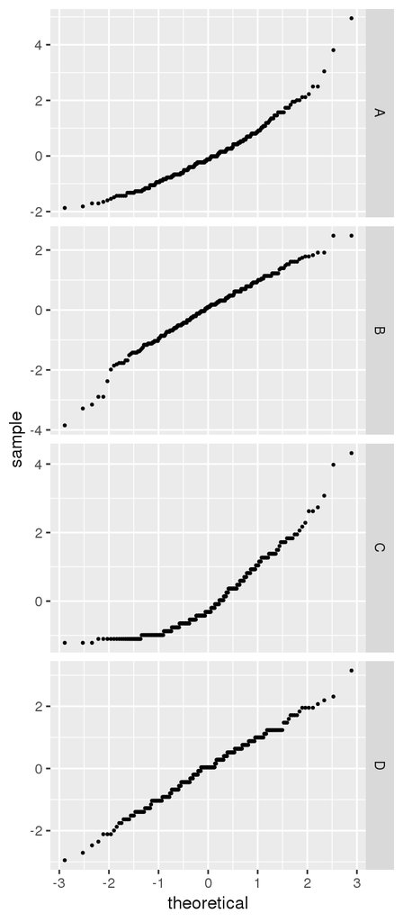

This is a product of OpenIntro that is released under a [Creative Commons Attribution-ShareAlike 3.0 Unported](http://creativecommons.org/licenses/by-sa/3.0). This lab was adapted for OpenIntro by Andrew Bray and Mine Çetinkaya-Rundel from a lab written by Mark Hansen of UCLA Statistics. These materials were adapted to functions in the `mosaic` and `ggformula` packages by Nicholas Horton and Bonnie Lin (Amherst College).